# Measuring the Impact of NCAA Football Head Coach Changes

By: Jack Miller, Alex Jackson, and Bryce Grove

# Introduction

Our project examines NCAA Division 1 football teams who made head coaching changes in the last ten seasons. Our goal is to measure the impact that first year head coaches have during their first season with a new team. We plan to do this by comparing various measures of success such as win percentage, touchdown differential, turnover differential, and offensive/defensive rank to the season before under the previous head coach. Our project is inspired by the recent success Duke’s football team has seen after the hiring of head coach Mike Elko after numerous sub-par seasons.

# Data Gathering and Cleaning

We started by gathering data from https://www.sports-reference.com/cfb/ which has college football data dating back to 2013 on both teams and coaches. We downloaded the csv’s of every college football season available as well as all of the head coach data that was available. After cleaning our datasets to eliminate potential conficts with joining the data, we were able to combine our datasets of different seasons into two main datasets with all of the team data and all of the coach data. Then, we were able to join the two new datasets (`coach_data` and `cfb_data`) into one big dataset (`big_data`) with all of the team data and coach’s record from each season dating back to 2013.

```r
#Load packages
library(tidyverse)
library(readr)
library(dplyr)
library(knitr)
library(stringr)
library(data.table)
library(broom)
library(gghighlight)
library(gapminder)
library(patchwork)
```

```r
#Load CSVs and Initial Data Cleaning
coach13 <- read_csv("Data/2013_Coaches.csv")
coach14 <- read_csv("Data/2014_Coaches.csv")
coach15 <- read_csv("Data/2015_Coaches.csv")
coach16 <- read_csv("Data/2016_Coaches.csv") %>%
  select(-Year) %>%
  mutate(Year = 2016)
coach17 <- read_csv("Data/2017_Coaches.csv")
coach18 <- read_csv("Data/2018_Coaches.csv")
coach19 <- read_csv("Data/2019_Coaches.csv")
coach20 <- read_csv("Data/2020_Coaches.csv")
coach21 <- read_csv("Data/2021_Coaches.csv")
cfb13 <- read_csv("Data/cfb13.csv") %>%
  mutate(Year = 2013) %>%
  mutate(Team = case_when(
    Team == "Miami (FL) (ACC)" ~ "Miami_FL (ACC)",
    Team == "Miami (OH) (MAC)" ~ "Miami_OH (MAC)",
    TRUE ~ Team
  )) %>% separate(col = "Team", into = "Team", sep = " [(]")
cfb14 <- read_csv("Data/cfb14.csv") %>%
  mutate(Year = 2014) %>%
  mutate(Team = case_when(
    Team == "Miami (FL) (ACC)" ~ "Miami_FL (ACC)",
    Team == "Miami (OH) (MAC)" ~ "Miami_OH (MAC)",
    TRUE ~ Team
  )) %>% separate(col = "Team", into = "Team", sep = " [(]")
cfb15 <- read_csv("Data/cfb15.csv") %>%
  mutate(Year = 2015) %>%
  mutate(Team = case_when(
    Team == "Miami (FL) (ACC)" ~ "Miami_FL (ACC)",
    Team == "Miami (OH) (MAC)" ~ "Miami_OH (MAC)",
    TRUE ~ Team
  )) %>% separate(col = "Team", into = "Team", sep = " [(]")
cfb16 <- read_csv("Data/cfb16.csv") %>%
  mutate(Year = 2016) %>%
  mutate(Team = case_when(
    Team == "Miami (FL) (ACC)" ~ "Miami_FL (ACC)",
    Team == "Miami (OH) (MAC)" ~ "Miami_OH (MAC)",
    TRUE ~ Team
  )) %>% separate(col = "Team", into = "Team", sep = " [(]")
cfb17 <- read_csv("Data/cfb17.csv") %>%
  mutate(Year = 2017) %>%
  mutate(Team = case_when(
    Team == "Miami (FL) (ACC)" ~ "Miami_FL (ACC)",
    Team == "Miami (OH) (MAC)" ~ "Miami_OH (MAC)",
    TRUE ~ Team
  )) %>% separate(col = "Team", into = "Team", sep = " [(]")
cfb18 <- read_csv("Data/cfb18.csv") %>%
  mutate(Year = 2018) %>%
  mutate(Team = case_when(
    Team == "Miami (FL) (ACC)" ~ "Miami_FL (ACC)",
    Team == "Miami (OH) (MAC)" ~ "Miami_OH (MAC)",
    TRUE ~ Team
  )) %>% separate(col = "Team", into = "Team", sep = " [(]")
cfb19 <- read_csv("Data/cfb19.csv") %>%
  mutate(Year = 2019) %>%
  mutate(Team = case_when(
    Team == "Miami (FL) (ACC)" ~ "Miami_FL (ACC)",
    Team == "Miami (OH) (MAC)" ~ "Miami_OH (MAC)",
    TRUE ~ Team
  )) %>% separate(col = "Team", into = "Team", sep = " [(]")
cfb20 <- read_csv("Data/cfb20.csv") %>%
  mutate(Year = 2020) %>%
  mutate(Team = case_when(
    Team == "Miami (FL) (ACC)" ~ "Miami_FL (ACC)",
    Team == "Miami (OH) (MAC)" ~ "Miami_OH (MAC)",
    TRUE ~ Team
  )) %>% separate(col = "Team", into = "Team", sep = " [(]")
cfb21 <- read_csv("Data/cfb21.csv") %>%
  mutate(Year = 2021) %>%
  select(-"...1") %>%
  separate(col = "Team", into = "Team", sep = " [(]")
```

```r
#Combine datasets to make one big dataset
names(cfb21) <- make.names(names(cfb21), unique=TRUE)
cfb_data <- bind_rows(cfb13, cfb14, cfb15, cfb16, cfb17, cfb18, cfb19, cfb20,
                      cfb21)
coach_data <- bind_rows(coach13, coach14, coach15, coach16, coach17, coach18,
                        coach19, coach20, coach21)
names(coach_data)[3] <- "Team"
cfb_data <- cfb_data %>%
  select(-c("...41", "Kickoff.Return.Def.Rank", "Opp.Kickoff.Returns",
            "Kickoff.Touchbacks", "Opponent.Kickoff.Return.Yards",
            "Opp.Kickoff.Return.Touchdowns.Allowed",
            "Avg.Yards.per.Kickoff.Return.Allowed", "Win.Loss", "NA.",
            "Interceptions.Thrown.y"))
coach_data <- coach_data %>%
  filter(W + L > 7)
cfb_data[cfb_data == "App State"] <- "Appalachian State"
cfb_data[cfb_data == "Appalachian St."] <- "Appalachian State"
cfb_data[cfb_data == "Arizona St."] <- "Arizona State"
cfb_data[cfb_data == "Arkansas St."] <- "Arkansas State"
cfb_data[cfb_data == "Army West Point"] <- "Army"
cfb_data[cfb_data == "Ball St."] <- "Ball State"
cfb_data[cfb_data == "Boise St."] <- "Ball State"
cfb_data[cfb_data == "Central Mich."] <- "Central Michigan"
cfb_data[cfb_data == "Coastal Caro."] <- "Coastal Carolina"
cfb_data[cfb_data == "Colorado St."] <- "Colorado State"
cfb_data[cfb_data == "UConn"] <- "Connecticut"
cfb_data[cfb_data == "Eastern Mich."] <- "Eastern Michigan"
cfb_data[cfb_data == "Fla. Atlantic"] <- "Florida Atlantic"
cfb_data[cfb_data == "FIU"] <- "Florida International"
cfb_data[cfb_data == "Florida St."] <- "Florida State"
cfb_data[cfb_data == "Fresno St."] <- "Fresno State"
cfb_data[cfb_data == "Ga. Southern"] <- "Georgia Southern"
cfb_data[cfb_data == "Georgia St."] <- "Georgia State"
cfb_data[cfb_data == "Iowa St."] <- "Iowa State"
cfb_data[cfb_data == "Kansas St."] <- "Kansas State"
cfb_data[cfb_data == "Kent St."] <- "Kent State"
cfb_data[cfb_data == "La.-Monroe"] <- "Louisiana-Monroe"
cfb_data[cfb_data == "ULM"] <- "Louisiana-Monroe"
cfb_data[cfb_data == "Michigan St."] <- "Michigan State"
cfb_data[cfb_data == "Middle Tenn."] <- "Middle Tennessee State"
cfb_data[cfb_data == "Mississippi St."] <- "Mississippi State"
cfb_data[cfb_data == "New Mexico St."] <- "New Mexico State"
cfb_data[cfb_data == "NIU"] <- "Norhtern Illinois"
cfb_data[cfb_data == "Northern Ill."] <- "Norhtern Illinois"
cfb_data[cfb_data == "Ohio St."] <- "Ohio State"
cfb_data[cfb_data == "Oklahoma St."] <- "Oklahoma State"
cfb_data[cfb_data == "Oregon St."] <- "Oregon State"
cfb_data[cfb_data == "Penn St."] <- "Penn State"
cfb_data[cfb_data == "San Diego St."] <- "San Diego State"
cfb_data[cfb_data == "San Jose St."] <- "San Jose State"
cfb_data[cfb_data == "South Fla."] <- "South Florida"
cfb_data[cfb_data == "Southern Miss."] <- "Southern Mississippi"
cfb_data[cfb_data == "Southern California"] <- "USC"
cfb_data[cfb_data == "Western Mich."] <- "Western Michigan"
cfb_data[cfb_data == "Western Ky."] <- "Western Kentucky"
cfb_data[cfb_data == "Washington St."] <- "Washington State"
cfb_data[cfb_data == "Utah St."] <- "Utah State"
cfb_data[cfb_data == "Texas St."] <- "Texas State"
coach_data[coach_data == "Bowling Green State"] <- "Bowling Green"
coach_data[coach_data == "Brigham Young"] <- "BYU"
coach_data[coach_data == "North Carolina State"] <- "NC State"
coach_data[coach_data == "Pitt"] <- "Pittsburgh"
coach_data[coach_data == "Miami (FL)"] <- "Miami_FL"
coach_data[coach_data == "Miami (OH)"] <- "Miami_OH"
big_data <- inner_join(cfb_data, coach_data, by = c("Team", "Year")) %>%
  select(c(Team, Coach, W, L, Pct, Year, Conf, Total.Points, Points.Allowed,
          Off.Rank, Off.Yards.Play, Turnover.Margin, Def.Rank, Touchdowns,
          Penalties, Penalty.Yards.Per.Game, Yards.Play.Allowed,
          Off.TDs.Allowed, Scoring.Off.Rank, Avg.Points.per.Game.Allowed,
          Touchdowns.Allowed))
```

# Modeling and Data Analysis

To examine the impact of first year coaches, we first need to identify seasons in which the head coach is in his first year. To do this, we created a for loop that checks if the previous observation is of the same team and a different coach. Because the observations are ordered by school name and then year, we know that two observations of the same school indicate back-to-back seasons. If the previous row was the same team and a different head coach, then we assign the indicator variable `new_coach` to be 1. If the coach is the same as the previous year or if the observation above is a different team (there is no older data for the team being examined), then `new_coach` is assigned a value of 0. After we identified rows that were back-to-back seasons, we created lag variables for certain statistics from the season before including touchdowns, turnover differential, win percentage, touchdowns allowed, and offensive and defensive rank. Then, each observation that also had data from the previous season contained the statistics of the first season under the new head coach as well as the statistics from the final season of the old head coach. For the statistics we were considering, we created `delta` variables that measure the change in the statistic from previous season. For example, `delta_pct` is the winning percentage of the first season under the new head coach minus the winning percentage of the last season under the old coach. We then created linear regression models to test if `new_coach` is a significant predictor on any of the `delta` variables.

```r
new_coach = c()
big_data <- big_data %>%
  arrange(Team, Year)
loop_data <- big_data %>%
    group_by(Team)
for (i in 2:nrow(big_data)){
  if ((big_data$Team[i] == big_data$Team[i-1]) & (big_data$Coach[i] !=
                                                  big_data$Coach[i-1])){
    new_coach = append(new_coach, 1)
  }
  else{
    new_coach = append(new_coach, 0)
  }
}

big_data <- big_data[-1, ] %>%
  cbind(new_coach)
big_data <- big_data %>%
  mutate(new_coach = as.factor(new_coach))

old_data <- big_data %>% select(c("Turnover.Margin", "Touchdowns", "Scoring.Off.Rank"))
new_data <- paste("lag", old_data, sep = ".")

big_data <-
  big_data %>%
  group_by(Team) %>%
  mutate(lastyr_TD = lag(Touchdowns, n = 1, default = NA),
         lastyr_TOmargin = lag(Turnover.Margin, n = 1, default = NA),
         lastyr_pct = lag(Pct, n = 1, default = NA),
         lastyr_TD.allowed = lag(Off.TDs.Allowed, n = 1, default = NA),
         lastyr_Offrank = lag(Off.Rank, n = 1, default = NA),
         lastyr_Defrank = lag(Def.Rank, n = 1, default = NA),
         delta_TOmargin = Turnover.Margin - lastyr_TOmargin,
         delta_TD = Touchdowns - lastyr_TD,
         delta_pct = Pct - lastyr_pct,
         delta_TD.allowed = Off.TDs.Allowed - lastyr_TD.allowed,
         delta_Offrank = Off.Rank - lastyr_Offrank,
         delta_Defrank = Def.Rank - lastyr_Defrank) %>%
  filter(Year != 2013)

lm.1 <- lm(delta_pct ~ new_coach, data = big_data)
lm.2 <- lm(delta_TD.allowed ~ new_coach, data = big_data)
lm.3 <- lm(delta_TD ~ new_coach, data = big_data)
lm.4 <- lm(delta_TOmargin ~ new_coach, data = big_data)
lm.5 <- lm(delta_Offrank ~ new_coach, data = big_data)
lm.6 <- lm(delta_Defrank ~ new_coach, data = big_data)
tidy(lm.1) %>%
  kable(digits = 3)
```

| term | estimate | std.error | statistic | p.value |
| --- | --- | --- | --- | --- |
| (Intercept) | 0.007 | 0.008 | 0.928 | 0.354 |
| new_coach1 | -0.031 | 0.018 | -1.741 | 0.082 |

```r
tidy(lm.2) %>%
  kable(digits = 3)
```

| term | estimate | std.error | statistic | p.value |
| --- | --- | --- | --- | --- |
| (Intercept) | -0.208 | 0.422 | -0.492 | 0.623 |
| new_coach1 | 0.553 | 0.970 | 0.570 | 0.569 |

```r
tidy(lm.3) %>%
  kable(digits = 3)
```

| term | estimate | std.error | statistic | p.value |
| --- | --- | --- | --- | --- |
| (Intercept) | 0.462 | 0.559 | 0.827 | 0.409 |
| new_coach1 | -3.281 | 1.284 | -2.555 | 0.011 |

```r
tidy(lm.4) %>%
  kable(digits = 3)
```

| term | estimate | std.error | statistic | p.value |
| --- | --- | --- | --- | --- |
| (Intercept) | 0.205 | 0.348 | 0.590 | 0.556 |
| new_coach1 | -1.147 | 0.799 | -1.435 | 0.152 |

```r
tidy(lm.5) %>%
  kable(digits = 3)
```

| term | estimate | std.error | statistic | p.value |
| --- | --- | --- | --- | --- |
| (Intercept) | -0.871 | 1.349 | -0.646 | 0.519 |
| new_coach1 | 4.731 | 3.099 | 1.527 | 0.127 |

```r
tidy(lm.6) %>%
  kable(digits = 3)
```

| term | estimate | std.error | statistic | p.value |
| --- | --- | --- | --- | --- |
| (Intercept) | -0.047 | 1.35 | -0.034 | 0.973 |
| new_coach1 | 3.701 | 3.10 | 1.194 | 0.233 |

Our model outputs above do not show much about `new_coach`, but it does show that `new_coach` is significant in predicting the change in touchdowns scored using an $\alpha$-level of 0.05. The coefficient is negative, which means that teams with new coaches are statistically more likely to see a regression in touchdowns from the year before than teams with returning coaches. However, there are many outside lurking variables as well as numerous different types of head coaching changes as we mention in the discussion. For this reason, it is very hard to group every new coaching observation together and even harder to make generalized predictions about teams using only whether or not they have a new head coach. Still, it makes sense that teams with a new head coach would score less on average than teams without a new head coach.

# Visualizations

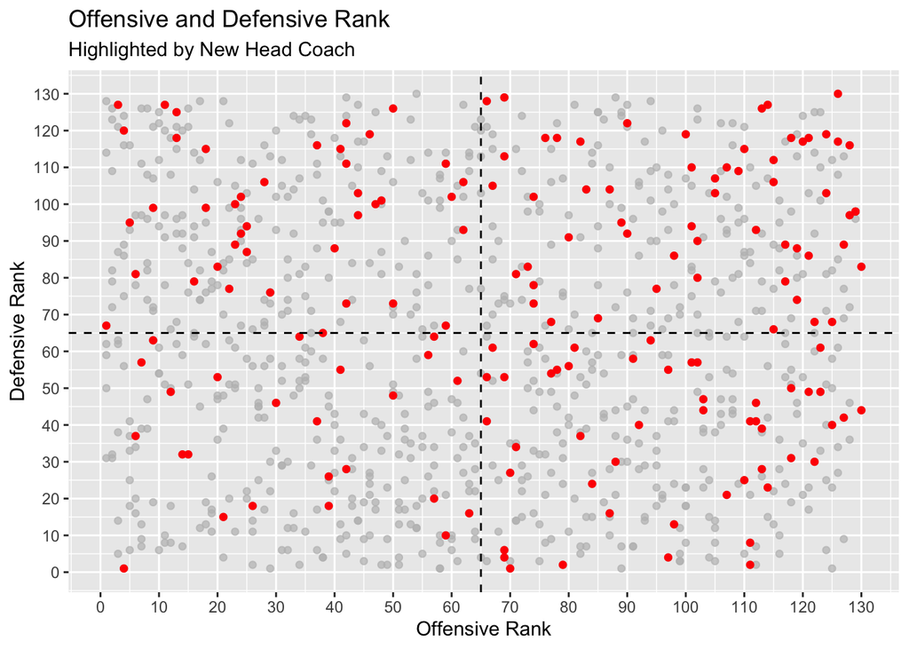

```r
big_data %>%
  ggplot(aes(x=Off.Rank, y=Def.Rank)) +
  geom_point(color = "red") +
  gghighlight::gghighlight(new_coach == 1) +
  scale_x_continuous(breaks = seq(0, 150, 10)) +
  scale_y_continuous(breaks = seq(0, 150, 10)) +
  geom_vline(xintercept = 65, linetype ="dashed") +
  geom_hline(yintercept = 65, linetype ="dashed") +
  labs(title = "Offensive and Defensive Rank", subtitle = "Highlighted by New Head Coach", x = "Offensive Rank", y = "Defensive Rank")
```

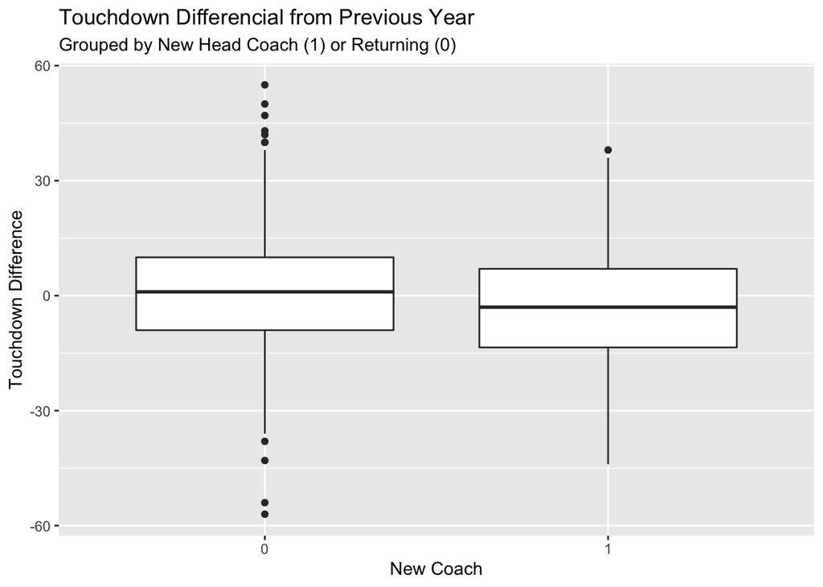

```r
big_data %>%
  group_by(new_coach) %>%
  ggplot(aes(x = new_coach, y = delta_TD)) +
  geom_boxplot() +
  labs(title = "Touchdown Differencial from Previous Year",
       subtitle = "Grouped by New Head Coach (1) or Returning (0)",
       x = "New Coach", y = "Touchdown Difference")
```

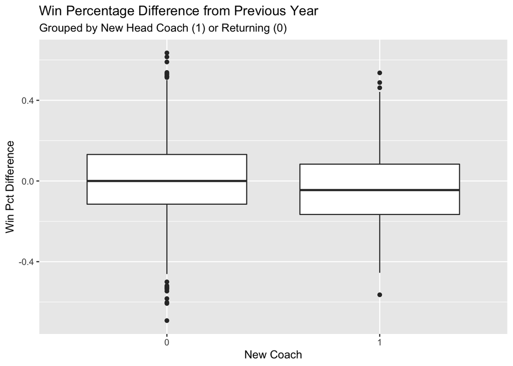

```r
big_data %>%
  group_by(new_coach) %>%
  ggplot(aes(x = new_coach, y = delta_pct)) +
  geom_boxplot() +
  labs(title = "Win Percentage Difference from Previous Year",
       subtitle = "Grouped by New Head Coach (1) or Returning (0)",
       x = "New Coach", y = "Win Pct Difference")
```

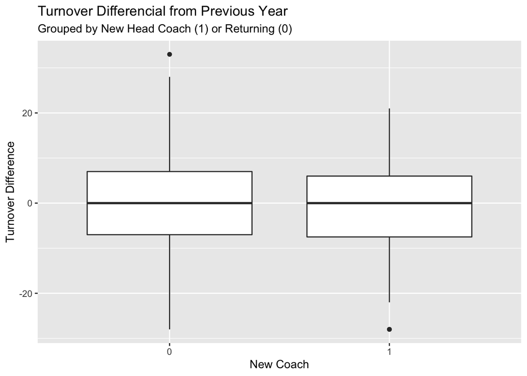

```r
big_data %>%
  group_by(new_coach) %>%
  ggplot(aes(x = new_coach, y = delta_TOmargin)) +
  geom_boxplot() +
  labs(title = "Turnover Differencial from Previous Year", subtitle = "Grouped by New Head Coach (1) or Returning (0)", x = "New Coach", y = "Turnover Difference")
```

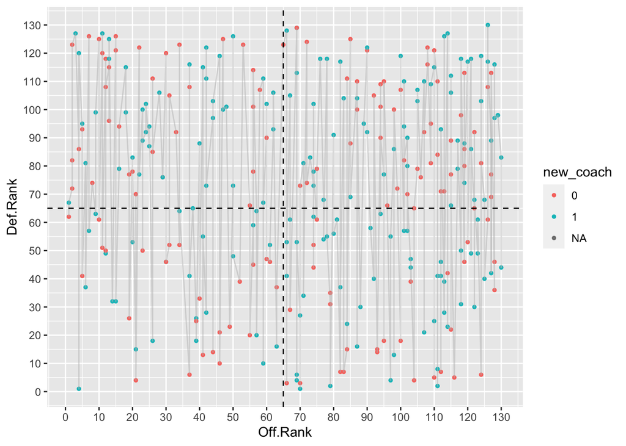

```r
test_data <- big_data %>%
  mutate(include = case_when(
    new_coach == 1 ~ 1,
    lead(new_coach, 1) == 1 ~ 1,
    T ~ 0
  )) %>%
  filter(include == 1) %>%
  mutate(group_no = 0)

for(i in seq(1, nrow(test_data), 2)){
  test_data[i, 32] = i
  test_data[i+1, 32] = i
  i = i+2
}

test_data %>%
  ggplot(aes(x=Off.Rank, y=Def.Rank, color = new_coach)) +
  geom_point(aes(fill = new_coach), size = 1) +
  geom_line(aes(group = group_no),
              color = "gray",
              alpha = .5,
              arrow = arrow(type = "closed",
                    length = (unit(.0075, "inches")))) +
  scale_x_continuous(breaks = seq(0, 150, 10)) +
  scale_y_continuous(breaks = seq(0, 150, 10)) +
  geom_vline(xintercept = 65, linetype ="dashed") +
  geom_hline(yintercept = 65, linetype ="dashed")
```

We can see from the boxplots that there is a small difference when comparing the change in win percentage, touchdown differential, and turnover differential from year to year for new head coaches vs. returning head coaches. As we discussed before, this is to be expected when comparing all new head coaches to all previous head coaches. In the next part, we will compare new head coaches only to head coaches in their final year (before they either left or got fired).

# Further Modeling

```r
lm.1t <- lm(delta_pct ~ new_coach, data = test_data)
lm.2t <- lm(delta_TD.allowed ~ new_coach, data = test_data)
lm.3t <- lm(delta_TD ~ new_coach, data = test_data)
lm.4t <- lm(delta_TOmargin ~ new_coach, data = test_data)
lm.5t <- lm(delta_Offrank ~ new_coach, data = test_data)
lm.6t <- lm(delta_Defrank ~ new_coach, data = test_data)
tidy(lm.1t) %>%
  kable(digits = 3)
```

| term | estimate | std.error | statistic | p.value |
| --- | --- | --- | --- | --- |
| (Intercept) | -0.046 | 0.018 | -2.598 | 0.010 |
| new_coach1 | 0.022 | 0.024 | 0.935 | 0.351 |

```r
tidy(lm.2t) %>%
  kable(digits = 3)
```

| term | estimate | std.error | statistic | p.value |
| --- | --- | --- | --- | --- |
| (Intercept) | 154.435 | 7.618 | 20.272 | 0.000 |
| new_coach1 | 0.121 | 10.241 | 0.012 | 0.991 |

```r
tidy(lm.3t) %>%
  kable(digits = 3)
```

| term | estimate | std.error | statistic | p.value |
| --- | --- | --- | --- | --- |
| (Intercept) | -1.375 | 1.364 | -1.008 | 0.314 |
| new_coach1 | -1.444 | 1.828 | -0.790 | 0.430 |

```r
tidy(lm.4t) %>%
  kable(digits = 3)
```

| term | estimate | std.error | statistic | p.value |
| --- | --- | --- | --- | --- |
| (Intercept) | -0.787 | 0.838 | -0.939 | 0.349 |
| new_coach1 | -0.155 | 1.123 | -0.138 | 0.890 |

```r
tidy(lm.5t) %>%
  kable(digits = 3)
```

| term | estimate | std.error | statistic | p.value |
| --- | --- | --- | --- | --- |
| (Intercept) | 4.132 | 3.411 | 1.211 | 0.227 |
| new_coach1 | -0.273 | 4.571 | -0.060 | 0.952 |

```r
tidy(lm.6t) %>%
  kable(digits = 3)
```

| term | estimate | std.error | statistic | p.value |
| --- | --- | --- | --- | --- |
| (Intercept) | 2.037 | 3.382 | 0.602 | 0.547 |
| new_coach1 | 1.618 | 4.532 | 0.357 | 0.721 |

# Discussion

Both the above visualizations and regressions show that there is a very weak, or even non-existent, relationship between a team having a new coach and performance versus the previous year. Again, this is not surprising given the two conflicting ways a new coach is needed in a program: the old coach was bad enough to get fired, or was good enough that he was poached by another program. We discuss this more in limitations, but the difficulties of transforming a team in just 1 year should be obvious, so it is again unsurprising that we don’t see particularly noteworthy changes year-to-year with new coaches versus off seasons without a coaching transition.

# Limitations and Future Research

Future projects would also explore how the background of new hires may determine success. It is a common idea that defensive coordinators often perform worse as head coaches than other head coaches or offensive-minded coaches, so it would be interesting to see if this claim holds any merit.